# fixed_lenght

.:: به نام خدا::.

تکلیف سری چهارم درس یادگیری ژرف

نام-نام خانوادگی

شماره دانشجویی

در قسمت اول این گزارش ، هدف، مشخص کردن نقش کلمات در جمله است و علاوه بر آن در شرایطی که مجموعه ای از کلمات یک نقش داشته باشند کلمه اول با پیشوند B و بقیه با پیشوند I مشخص گردند. ایده‌ای که در اینجا در نظر گرفته شده است این است که جملات به صورت دنباله‌ای از واژگان به شبکه داده شوند و خروجی برچسب هر واژه می‌باشد. در این صورت کل دنباله ی ورودی و خروجی هم بعد میگردد. هم چنین د راین قسمت، طول کل جملات داده های آموزشی را هم طول کرده (طول همه ی جملات را برابر با بزرگترین جمله داده اموزشی قرار داده و به عنوان ورودی داده اموزشی به شبکه میدهیم.) و باید توجه شود که هنگام تخمین جمله جدید الزامی نداریم که طول دنباله جدید هم اندازه با دنباله‌های آموزشی باشد.

```python
import numpy as np
import keras
from keras.models import Sequential
from keras.models import Sequential, Model
from keras.layers import Dense
from keras.layers import LSTM, RNN, GRU, SimpleRNN, TimeDistributed, Activation, Embedding, RepeatVector, Bidirectional
from keras.optimizers import RMSprop
from keras.utils.np_utils import to_categorical
from gensim.scripts.glove2word2vec import glove2word2vec
from gensim.models import KeyedVectors
from matplotlib import pyplot as plt
from sklearn.metrics import confusion_matrix
```

ابتدا لازم است که دیتاهای آموزشی لود شوند. بدین منظور به جهت کم تر کردن نیاز به دیتاهای آموزشی بیشتر و از آن جا که حروف بزرگ و کوچک، تفاوتی در معنا و تشخیص نقش کلمه ایجاد نمی کند تمام حروف را به حروف کوچک تبدیل کرده و به عنوان ورودی به شبکه وارد میکینم. هم چنین، طبق الگوی دیتاهای آموزشی داده شده، پایان هر جمله را با دستور "". . O" مشخص مینماییم.

```python
# load data:
data = open('./train.data', 'r').read().lower()
# convert data into sentences:
sentences = data.split('. . o\n\n')[0:-1]
len(sentences)
```

```
72
```

مشخص است که کل جملات داده های train یا آموزشی به تعداد 72 جمله است.

```python
sentences[0]
```

```
"confidence nn b-np\nin in b-pp\nthe dt b-np\npound nn i-np\nis vbz b-vp\nwidely rb i-vp\nexpected vbn i-vp\nto to i-vp\ntake vb i-vp\nanother dt b-np\nsharp jj i-np\ndive nn i-np\nif in b-sbar\ntrade nn b-np\nfigures nns i-np\nfor in b-pp\nseptember nnp b-np\n, , o\ndue jj b-adjp\nfor in b-pp\nrele…
```

ابتدا 4 لیست تعریف میگردد. به این صورت که X_data برای کلمات جمله Y_data به عنوان لیبل هر کلمه. words به منظور ذخیره کلمات و نیز متغیر chunks به منظور sort . و ذخیره کردن لیبل ها انتخاب میگردند. سپس کلمات و نقش های انان از یکدیگر جدا گشته و در متغیرهای مربوطه ذخیره میگردند. هم چنین ، همانگونه که در ابتدا بیان گردید کلمه دوم یک عبارت با توجه به الگوی منظمی که وجود دارد نیاز به ذخیره سازی ندارد.

```python
X_data = []  # container for sentences
Y_data = []  # container for labels
words = []  # this is our vocabulary
chunks = [] # this is our chunk labels
for i in range(len(sentences)):
    x = [] # temporary containers
    y = []
    # each line in a sentence contain 3 parts: 1) word, 2) speech label  and 3) chunck label:
    line = sentences[i].splitlines()
    for j in range(len(line)):
        # some lines contain just one space, that doesn't follow any rule we defined.
        # so those lines simple ignored.
        if len(line[j].split(' ')) == 3:
            w, _, c = line[j].split(' ')
            x.append(w)
            y.append(c)
            words.append(w)
            chunks.append(c)
    # add '.' after the last word of sentence, and add 'o' as last label for '.':
    X_data.append(' '.join(x)+'.')
    Y_data.append(' '.join(y)+' o')
```

```python
X_data[0]
```

```
"confidence in the pound is widely expected to take another sharp dive if trade figures for september , due for release tomorrow , fail to show a substantial improvement from july and august 's near-record deficits."
```

```python
Y_data[0]
```

```
'b-np b-pp b-np i-np b-vp i-vp i-vp i-vp i-vp b-np i-np i-np b-sbar b-np i-np b-pp b-np o b-adjp b-pp b-np b-np o b-vp i-vp i-vp b-np i-np i-np b-pp b-np i-np i-np b-np i-np i-np o'
```

عبارت \n به عنوان padding و عبارت پایان دهنده جمله اضافه شده اند.

```python
chars = list(set(''.join(words)))
chars.sort()
chars = [' '] + chars
# create targets (label)
label = list(set(chunks))
label.sort()
label = ['\n'] + label
```

```python
print(label)
```

```
['\n', 'b-adjp', 'b-advp', 'b-np', 'b-pp', 'b-prt', 'b-sbar', 'b-vp', 'i-adjp', 'i-advp', 'i-np', 'i-pp', 'i-sbar', 'i-vp', 'o']
```

برچسب‌های خروجی برای شبکه قابل فهم نیستند و لازم است به صورت داده‌های دسته بندی ( categorical ) تبدیل شوند. برای این کار ابتدا دنباله خروجی به دنباله‌ای از اعداد و سپس به بردارهای one-hot coded نگاشت می‌شوند. در مرحله اول این کار با استفاده از تابع زیر انجام می‌شود:

```python
def label_encode(l):
    return [label.index(i) for i in l.split(' ')] + [0]

print(label_encode(Y_data[0]))
```

```
[3, 4, 3, 10, 7, 13, 13, 13, 13, 3, 10, 10, 6, 3, 10, 4, 3, 14, 1, 4, 3, 3, 14, 7, 13, 13, 3, 10, 10, 4, 3, 10, 10, 3, 10, 10, 14, 0]
```

در سلول زیر لیستی از شامل دنباله‌هایی از برچسب‌های خروجی برای جملات داده‌های آموزش تولید می‌شود.

```python
Y = [label_encode(Y_data[i]) for i in range(len(Y_data))]
```

همچنین برای آماده سازی داده‌های آموزش نیاز داریم که جملات را از نظر واژگان هم طول نماییم. به این منظور می‌بایست بیشترین طول جملات را داشته باشیم. در سلول زیر بیشترین طول محاسبه می‌شود:

```python
maxlen = max([len(Y[i]) for i in range(len(Y))])
maxlen
```

```
57
```

در ادامه رشته کدهای خروجی را به صورت one-hot vector تبدیل می‌کنیم. توجه شود که به انتهای جملات یک کد توقف یا padding اضافه شده است. برای تبدیل خروجی‌ها به دنباله one-hot vector از تابع آماده کتابخانه keras یعنی دستور to_categorical استفاده شده است.

```python
y = np.zeros((len(Y), maxlen+1, len(label)))
for i in range(y.shape[0]):
    T = Y[i]
    for j in range(len(T)):
        y[i, j]= to_categorical(T[j], num_classes=len(label))
```

```python
to_categorical(2, num_classes=5)
```

```
array([0., 0., 1., 0., 0.], dtype=float32)
```

برای بررسی کدینگ درست برچسب‌های خروجی، در سلول زیر برای جمله اول خروجی به همراه کد padding نشان داده شده است.

```python
y[0].argmax(-1)
```

[output not shown]

پس از آماده سازی داده‌های خروجی برای آموزش، حال نوبت به داده‌های ورودی می‌رسد. این که داده‌های ورودی به چه صورتی انجام شوند. این که چگونه داده‌های ورودی را آماده کنیم، تأثیر مهمی در معماری شبکه خواهد داشت. راهکارهای مختلفی که می‌تواند در اینجا مطرح شود دو حالت character-level و word-level می‌باشد. در حالت اول طول دنباله ورودی و خروجی مشابه نمی‌باشد. بنابراین معماری مورد استفاده حالت پیچیده ساختار «ماشین ترجمه» پیشنهاد می‌شود. اما در حالت دوم با توجه به این که دنباله ورودی و خروجی هم طول و برابر تعداد واژگان یک جمله هستند، بنابراین ساختار شبکه بسیار ساده‌تر خواهد بود. در اینجا ساختار دوم پیاده سازی شده است.

اما اگر بخواهیم که مدل را در سطح واژگان پیاده سازی کنیم، نیاز است که واژه‌های ورودی ابتدا به بردارهایی کد شوند. می‌توانیم در ابتدای مدل خود یک لایه برای word embedding قرار دهیم. اما به دلیل این که برای واژگان انگلیسی این کار پیشتر انجام شده است، ما از کدینگ آماده word2vec استفاده می‌کنیم. برای این منظور از کتابخانه پایتونی gensim و مدل عمومی از پیش آموزش دیده glove.6B توسط دانشگاه استنفورد استفاده می‌کنیم. و سپس مدل glove را به مدل word2vec تبدیل می‌نماییم.

```python
glove_input_file = 'glove.6B.100d.txt'
word2vec_output_file = 'glove.6B.100d.txt.word2vec'
glove2word2vec(glove_input_file, word2vec_output_file)
```

```
(400000, 100)
```

```python
filename = 'glove.6B.100d.txt.word2vec'
w2v = KeyedVectors.load_word2vec_format(filename, binary=False )
```

در اینجا از بردارهای ۱۰۰ تایی برای کد استفاده کردیم. در زیر یک مثال از این بردارها نشان داده شده است.

```python
w2v['while']
```

```
array([ 0.094157 ,  0.46457  ,  0.4535   , -0.15074  ,  0.27223  ,
        0.4545   , -0.14906  ,  0.15345  , -0.061775 , -0.080787 ,
        0.53914  , -0.39179  ,  0.083668 , -0.10328  ,  0.27425  ,
       -0.80995  , -0.11588  , -0.32288  , -0.23434  ,  0.19782  ,
        0.47749  ,  0.027463 ,  0.49629  ,  0.41455  ,  0.55198  ,
        0.13814  , -0.14193  , -0.65181  , -0.055301 , -0.026074 ,
       -0.26557  ,  0.16076  , -0.32292  , -0.10203  ,  0.08234  ,
        0.13615  ,  0.27754  ,  0.19405  , -0.2348   , -0.12201  ,
       -0.39889  , -0.6782   ,  0.42633  ,  0.21963  , -0.20309  ,
        0.16836  ,  0.013425 , -0.35281  , -0.069011 , -0.93563  ,
        0.16361  , -0.13117  ,  0.099808 ,  1.8998   , -0.26605  ,
       -2.4321   , -0.34386  , -0.46084  ,  1.3691   ,  0.72702  ,
       -0.18504  ,  0.18016  ,  0.085648 ,  0.46807  ,  0.12802  ,
        0.28034  ,  0.68951  ,  0.36221  ,  0.66845  ,  0.32295  ,
       -0.58005  , -0.27069  ,  0.15057  , -0.46084  , -0.21336  ,
        0.36952  , -0.23539  ,  0.075712 , -0.71302  , -0.27551  ,
        0.64845  ,  0.10345  , -0.64706  ,  0.29101  , -1.4154   ,
       -0.31586  , -0.26086  ,  0.24959  , -0.20852  , -0.28688  ,
       -0.075658 , -0.63833  , -0.0040848,  0.21971  , -0.91796  ,
        0.271    , -0.30677  , -0.23741  ,  0.69147  , -0.16581  ],
      dtype=float32)
```

با توجه به این که مدل glove با داده‌های عمومی ویکیپدیا آموزش داده شده است، بنابراین الزاما دارای همه واژگان پایگاه داده ما نمی‌باشد. در این صورت برای واژگانی که در مدل word2vec تعریف نشده‌اند ما یک کد ناشناس که یک بردار ۱۰۰ تایی منفی یک است استفاده می‌کنیم. نکته‌ای که باید در نظر گرفته شود این است که این روش کد گذاری تأثیر منفی آنچنانی در خروجی کار نمی‌گذارد، برای این که نقش واژگان در یک جمله به صورت سلسه مراتبی قابل پیش‌بینی است و ارتباط مستقیمی به جنس آن واژه ندارد. حال اگر در میان واژگان جمله‌ای عبارت ناشناس باشد، باز نقش ان بر اساس نقش کلمات پیش و پس از آن قابل شناسایی است.

```python
UKN = -np.ones((1,100))
```

در سلول زیر، داده‌های ورودی آموزشی با استفاده از word2vec کدگذاری می‌شوند. طول جملات نیز در اینجا مشابه برچسب‌ها یکی بیشتر از طول جمله‌ها می‌باشد و آخرین عبارت معرف کد پایان جمله یا همان \n می‌باشد.

```python
E = []
x = np.zeros((len(X_data), maxlen+1, 100))
for i in range(len(X_data)):
    # each words splited by single space:
    T = X_data[i].split(' ')
    # T is the words of i-th sentence
    for j in range(len(T)):
        # here just checked if the w2v model contained the input word or not:
        try:
            # T[j] is j-th word of i-th sentence
            x[i, j]= w2v[T[j]]
        except:
            E.append(T[j])
            x[i, j] = UKN
```

```python
print(E)
# Unknown words on the data set:
```

```
['deficits.', 'week.', 'thursday.', 'say.', 'dillow', 'institute.', '-lrb-', '-rrb-', 'august.', '1988.', 'exports.', 'inflows.', 'september.', 'dillow', 'stockbuilding', 'imports.', 'billion.', 'positions.', 'pound.', 'clouded.', 'effect.', 'years.', 'quickly.', 'ago.', '1988.', 'dillow', 'rises.',…
```

```python
x.shape
```

```
(72, 58, 100)
```

```python
y.shape
```

```
(72, 58, 15)
```

با توجه به این که برخی از واژگان ورودی در مدل word2vec موجود نیستند، بنابراین برای پیشبینی نقش آن‌ها می‌توان از کلمات پیش و پس از آن‌ها استفاده کرد، برای این منظور مدلی که تعریف می‌کنیم بجای استفاده از شبکه‌های بازگشتی یک‌طرفه، از ساختار دوطرفه یا bidirectional استفاده می‌کند. در مدل زیر از لایه Lstm استفاده شده است که به راحتی می‌توان آن را با GRU برای لایه‌های gru و SimpleRNN برای لایه‌های Rnn ساده عوض کرد. ولی شبکه در حالت‌هایی که لایه‌ها از جنس GRU و LSTM هستند زودتر و بهتر آموزش می‌بیند.

```python
hidden_size =  32
model = Sequential()
model.add(Bidirectional(LSTM(hidden_size, return_sequences=True), input_shape=(None, 100)))
model.add(Bidirectional(LSTM(hidden_size, return_sequences=True)))
```

```python
num_layers = 1
for _ in range(num_layers):
    model.add(Bidirectional(LSTM(hidden_size, return_sequences=True)))
model.add(TimeDistributed(Dense(len(label))))
model.add(Activation('softmax'))
optimizer = RMSprop(decay=1e-1)
model.compile(loss='categorical_crossentropy',
            optimizer='rmsprop',
            metrics=['accuracy'])
```

در لایه آخر، با توجه به این که اندازه خروجی شبکه برابر با ورودی شبکه می‌باشد، بنابراین از تمام دنباله لایه بازگشتی به لایه fully-connected متصل شده است. در Keras به این صورت عمل می‌شود که در لایه بازگشتی پارامتر return_sequences فعال می‌شود و سپس با استفاده با یک لایه TimeDistributed دنباله شبکه به طور سلسله مراتبی به دسته بند منتقل می‌شود. خلاصه‌ای از جزییات معماری شبکه در زیر نشان داده شده است.

```python
model.summary()
```

```
_________________________________________________________________
Layer (type)                 Output Shape              Param #
=================================================================
bidirectional_14 (Bidirectio (None, None, 64)          34048
_________________________________________________________________
bidirectional_15 (Bidirectio (None, None, 64)          24832
_________________________________________________________________
bidirectional_16 (Bidirectio (None, None, 64)          24832
_________________________________________________________________
time_distributed_6 (TimeDist (None, None, 15)          975
_________________________________________________________________
activation_6 (Activation)    (None, None, 15)          0
=================================================================
Total params: 84,687
Trainable params: 84,687
Non-trainable params: 0
_________________________________________________________________
```

```python
model.load_weights('lastWfixed')
```

در زیر داده‌های آموزش را به دو دسته آموزش و ارزیابی تقسیم می‌کنیم و با آن‌ها شبکه را آموزش می‌دهیم.

```python
idx = np.random.permutation(x.shape[0])
train_idx = idx[0:64]
val_idx = idx[64::]
```

آموزش شبکه در Keras با استفاده از دستور fit انجام می‌شود. پس از گذشت ۲۰۰ دوره زمانی، وزن‌های شبکه آموزش می‌بییند.

```python
model.fit(x[train_idx], y[train_idx], epochs=200, validation_data=(x[val_idx], y[val_idx]))
model.save_weights('lastWfixed')
```

```
Train on 64 samples, validate on 8 samples
```

حال ابتدا نتیجه شبکه را روی یکی از داده‌های ارزیابی، بررسی می‌کنیم. در سلول زیر خروجی پیشبینی شده شبکه مشاهده می‌شود:

```python
index = np.random.permutation(val_idx)[0]
l = model.predict(x[index:index+1])[0].argmax(-1)
l
```

```
array([ 3,  4,  3, 10, 10, 10, 10, 14,  3, 10,  7, 13,  4,  3, 10, 14,  3,
        4,  3, 10,  3, 10,  4,  3, 10, 14,  0,  0,  0,  0,  0,  0,  0,  0,
        0,  0,  0,  0,  0,  0,  0,  0,  0,  0,  0,  0,  0,  0,  0,  0,  0,
        0,  0,  0,  0,  0,  0,  0])
```

در اینجا نیز خروجی مطلوب به ازای ورودی قبلی نشان داده شده است:

```python
y[index].argmax(-1)
```

```
array([ 2,  4,  3, 10, 10, 10, 10, 14,  3, 10,  7, 13,  4,  3, 10, 14,  2,
        4,  3, 10,  3, 10,  4,  3, 10, 14,  0,  0,  0,  0,  0,  0,  0,  0,
        0,  0,  0,  0,  0,  0,  0,  0,  0,  0,  0,  0,  0,  0,  0,  0,  0,
        0,  0,  0,  0,  0,  0,  0])
```

برچسب‌های پیش‌بینی شده تا رسیدن به عبارت توقف:

```python
a = []
for i in range(l.shape[0]):
    c = label[l[i]]
    a.append(c)
    if c == '\n':
        break
print(a)
```

[output not shown]

برچسب‌های مطلوب:

```python
a = []
for i in range(len(Y[index])):
    a.append(label[Y[index][i]])
print(a)
```

[output not shown]

عبارت ارزیابی ورودی:

```python
X_data[index]
```

```
'late in the new york trading day , the dollar was quoted at 1.8578 marks , up from 1.8470 marks late thursday in new york.'
```

حال به طریق مشابه روی داده‌های تست نتیجه بررسی و گزارش می‌شود.

```python
# test one sample:
# load data:
data = open('./test.data', 'r').read().lower()
# convert data into sentences:
sentences = data.split('. . o\n\n')[0:-1]
```

می‌توان مشابه عبارت داده شده در صورت مساله به کمک دستورات زیر ، خروجی را به صورت تصویر تبدیل کرد. به این ترتیب که کلمات هم نقش با رنگهای مشابهی نشان داده شوند.

```python
img = np.ones((500, 2000, 3), dtype=np.uint8)*255
```

```python
print(label)
```

```
['\n', 'b-adjp', 'b-advp', 'b-np', 'b-pp', 'b-prt', 'b-sbar', 'b-vp', 'i-adjp', 'i-advp', 'i-np', 'i-pp', 'i-sbar', 'i-vp', 'o']
```

در سلول پایین یک تابع برای تخصیص رنگ به هر یک از ۱۵ برچسب مسأله تعریف شده است:

```python
COLOR = ['black', 'magenta', 'blue', 'green', 'yellow', 'cyan', (0.45,0.925,0.525), 'orange', 'red',
        (0.5,0.1, 0.1), (0.1,0.5,0.1), (0.1, 0.1, 0.5), (0.5, 0.1, 0.5), (0.5, 0.5, 0.1), (0.1, 0.5, 0.5)]
def getcolor(pos):
    if label.count(pos) != 0:
        return COLOR[label.index(pos)]
    else:
        return COLOR[0]
getcolor('b-sbar')
```

```
(0.45, 0.925, 0.525)
```

در سلول زیر، روی ۱۰ جمله نمونه از داده‌های تست، نتیجه پیش بینی شبکه به صورت رنگی و نمایشی بررسی می‌شود. به این صورت که در هر بلاک از تصویر دو خط نوشته می‌شود و در خط اول خروجی پیشبینی شبکه نمایش داده می‌شود و در خط دوم رنگ‌ها بر اساس برچسب‌ها مشخص می‌شوند.

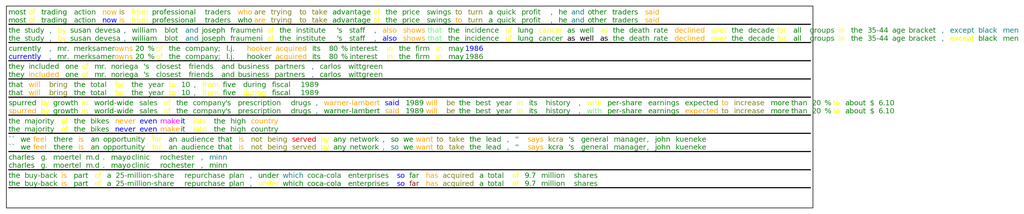

```python
#index = np.random.permutation(len(sentences))[0:10].tolist()
index = [355, 324, 465, 224, 375, 68, 688, 491, 526, 451]
#
plt.figure(figsize=(20, 30), dpi=180)
plt.imshow(img);
for idx in range(len(index)):
    X_test = []
    Y_test = []
    xt = []
    yt = []
    line = sentences[index[idx]].splitlines()
    for j in range(len(line)):
        if len(line[j].split(' ')) == 3:
            w, _, c = line[j].split(' ')
            xt.append(w)
            yt.append(c)
            #words.append(w)
            #chunks.append(c.split('-')[-1])
    X_test.append(' '.join(xt))
    Y_test.append(' '.join(yt))

    x_test = np.zeros((1,len(X_test[0].split(' ') + ['\n']), 100))

    T = X_test[0].split(' ')
    for j in range(len(T)):
        try:
            x_test[0, j]= w2v[T[j]]
        except:
            E.append(T[j])
            x_test[0, j] = UKN
    l = model.predict(x_test)[0].argmax(-1)

    a = []
    for i in range(l.shape[0]):
        c = label[l[i]]
        a.append(c)


    s = X_test[0].split(' ')
    #t = int(2000/len(s))
    pos = Y_test[0].split(' ')
    plt.text(x=5, y=20+(45*idx), s=s[0], color=getcolor(a[0]))
    plt.text(x=5, y=40+(45*idx), s=s[0], color=getcolor(pos[0]))
    st_x = len(s[0])*10+10
    for i in range(1, len(s)):
        plt.text(x=5+st_x, y=20+(45*idx), s=s[i], color=getcolor(a[i]))
        plt.text(x=5+st_x, y=40+(45*idx), s=s[i], color=getcolor(pos[i]))
        st_x += len(s[i])*10
        st_x += 11
    plt.hlines(40+45*idx+5, 5, 1995)
    plt.xticks([])
    plt.yticks([]);
```

در نهایت با استفاده از ماتریس آشفتگی تخمین می‌توان عمل کرد شبکه را روی کلاس‌های مختلف بررسی کرد.

```python
preds = []  # predicted labels
targets = [] # True labels
# loop over sentences:
for idx in range(len(sentences)):
    X_test = []
    Y_test = []
    xt = []
    yt = []
    line = sentences[idx].splitlines()
    # loop over words in one sentence and extract words and True labels
    for j in range(len(line)):
        if len(line[j].split(' ')) == 3:
            w, _, c = line[j].split(' ')
            xt.append(w)
            yt.append(c)

    X_test.append(' '.join(xt))
    Y_test.append(' '.join(yt))
    # word coding:
    x_test = np.zeros((1,len(X_test[0].split(' ') + ['\n']), 100))

    T = X_test[0].split(' ')
    for j in range(len(T)):
        try:
            x_test[0, j]= w2v[T[j]]
        except:
            x_test[0, j] = UKN
    # prediction:
    l = model.predict(x_test)[0].argmax(-1)

    # extract predicted labels
    a = []
    for i in range(l.shape[0]):
        a.append(l[i])

    # stack the predection in one list
    preds = preds + a

    # extract true labels
    pos = Y_test[0].split(' ') + ['\n']
    # some test labels arn't included in the train data set.
    # so here, they will be removed and considerd as \n
    for k in range(len(pos)):
        if label.count(pos[k]) == 0:
            pos[k] = '\n'
    # stack all targets in one list:
    t = [label.index(pos[i]) for i in range(len(pos))]
    targets = targets + t
```

```python
# calculate and predict the confusion matrix:
CM = confusion_matrix(y_pred=preds, y_true=targets)
for i in range(CM.shape[0]):
    for j in range(CM.shape[1]):
        print('%4d'%(CM[i,j]), end=' ')
    print()
```

```
  56   58   11    9    6    0    3  184    3   12  300    0    0   57   79
   0   23   17   45    5    0    0   17    1    1   29    0    0   29    5
   0   11   70   78   19    1    8   82    1    1   31    0    0   14   18
   3   31  114 3900   89    2   31   80    4    5  638    0    0   49  133
   0    3   22  119 1709    3   12   30    3    2   41    0    0   22   22
   0    2    7    7   13    0    1    2    0    0    1    0    0    5    1
   0    0   15   39   35    0   62    9    0    0    4    0    0    2   26
   0   28   72  156   78    0   16 1215    2    2  220    0    1   93   20
   0   11    5   12    1    0    2    4    5    0   21    0    0    6   12
   0    5    5    3    1    0    2    3    1    0    8    0    0    1    7
   8   31   44  292   59    0    3  240    4    5 4759    0    0   11  235
   0    0    0    4    9    0    0    0    0    0    0    0    0    0    2
   0    0    1    0    0    0    0    0    0    0    0    1    0    0    0
   0   29   37  168   34    7   12   90    1    4   21    0    0  644   14
   0    0   11   43   19    0   20   13    0    0   95    0    0    6 1596
```

```python
# calculate the accuracy of model:
acc = np.diag(CM) / CM.sum(1)
acc*100
```

```
array([ 7.19794344, 13.37209302, 20.95808383, 76.78676905, 85.96579477,
        0.        , 32.29166667, 63.84655807,  6.32911392,  0.        ,
       83.6232648 ,  0.        ,  0.        , 60.69745523, 88.51913478])
```

```python
# caluclate the precision of model:
prec = np.diag(CM) / CM.sum(0)
prec[6] = 0
prec*100
```

```
array([83.58208955,  9.9137931 , 16.2412993 , 80.        , 82.2821377 ,
        0.        ,  0.        , 61.70644997, 20.        ,  0.        ,
       77.15629053,  0.        ,  0.        , 68.58359957, 73.5483871 ])
```

**جمع بندی:**

در اینجا یک مدل برای تشخیص نقش کلمات در یک جمله ارایه شد. مدل ارایه شده یک مدل ساده اما نسبتاً کارآمد بر مبنای شبکه‌های بازگشتی و یک دسته بند است. اما با توجه به این که داده‌های آموزشی به اندازه کافی در اختیار نداریم، بنابراین مدل به طور مناسب آموزش نمی‌بیند. مسأله دیگر بعد برچسب‌ها است. که تعداد آن‌ها نسبت به یکدیگر بسیار نا متوازن می‌باشد و تاثیر جدی در روند آموزشی کلاس‌ها می‌گذارد. این اختلاف در ماتریس آشفتگی داده‌های آزمون و نیز دقت خروجی مشخص می‌باشد.